# Machin Learning Project

Lingfei Tang

December 27, 2015

# Overview

# Data Importing and Cleaning

We first imported the dataset and performed simple data cleaning steps to exclude NA values and empty columns. We verified that there were no zero variance variables.

```r
print(paste("Number of near zero variance variables is ", sum(nzv$nzv)))
```

```
## [1] "Number of near zero variance variables is  0"
```

To determine if many variables are highly correlated, we plotted the correlation matrix for all the predictors in the dataset. The following figure shows that there are few variables that are highly correlated (r > .8). Given the small number of the highly correlated cases, we included all the predictors in the machine learning algorithm.

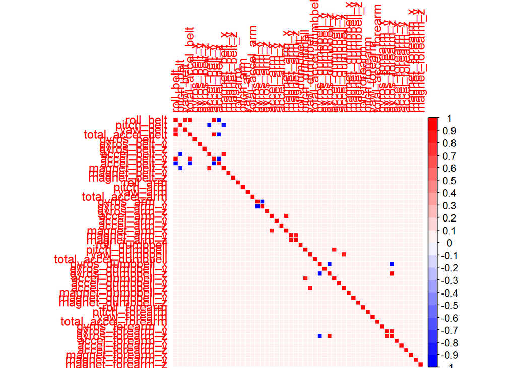

```r
#Correlation Matrix
 M <- cor(trainActivity[, -53])
 M8 <- M
 M8[abs(M8) < .8] <- 0
 corrplot::corrplot(M8, method="color", col=colorRampPalette(c("blue","white","red"))(20))
```

# Model Selection

As an exploratory analysis to determine the best model for the analysis, we first conducted a linear discriminant analysis (LDA) and a tree model (rpart) analysis to compare their accuracies. The result showed that both models had lower than .8 accuracy.

```r
set.seed(123)
inTrain <- createDataPartition(trainActivity$classe, p = .6, list=FALSE)
modFitLDA <- train(classe~., method="lda", data=trainActivity[inTrain,]) #Accuracy rate = .7
print(modFitLDA)
```

```
## Linear Discriminant Analysis
##
## 11532 samples
##    52 predictor
##     5 classes: 'A', 'B', 'C', 'D', 'E'
##
## No pre-processing
## Resampling: Bootstrapped (25 reps)
## Summary of sample sizes: 11532, 11532, 11532, 11532, 11532, 11532, ...
## Resampling results
##
##   Accuracy   Kappa      Accuracy SD  Kappa SD
##   0.7002661  0.6205553  0.006345211  0.007885237
##
##
```

```r
modFitTree <- train(classe~., method="rpart", data=trainActivity[inTrain,]) #Accuracy rate = .5
print(modFitTree)
```

```
## CART
##
## 11532 samples
##    52 predictor
##     5 classes: 'A', 'B', 'C', 'D', 'E'
##
## No pre-processing
## Resampling: Bootstrapped (25 reps)
## Summary of sample sizes: 11532, 11532, 11532, 11532, 11532, 11532, ...
## Resampling results across tuning parameters:
##
##   cp          Accuracy   Kappa       Accuracy SD  Kappa SD
##   0.03624682  0.4946486  0.33952928  0.04562456   0.07360653
##   0.05952237  0.4274630  0.22738935  0.06477078   0.10828123
##   0.11480179  0.3273948  0.06464974  0.04186066   0.06342188
##
## Accuracy was used to select the optimal model using  the largest value.
## The final value used for the model was cp = 0.03624682.
```

Random forest model is a non-parametric model that offers high accuracy for model prediction, but does not assume normality on the predictors. This model is suitable to predict categorical data, as the class variable for this movement dataset. Initial testing of the model showed higher than .8 accuracy rate for the same training data (code ommited due to long processing time). In the following chapter, we adopted a random forest model.

# Training and Cross-validation

To reduce the bias of the model, we applied a 10 fold cross-validation technique. We trained the model based on 9 of the 10 folds in the dataset, and tested the model based on the remaning fold of the dataset. Given the computational intensity of fitting a random forest model, we used parallel processing to speed up the model training process.

```r
cl <- makeCluster(4)
registerDoParallel(cl)

#Create k data folds
k=10
folds <- createFolds(trainActivity$classe, k=k)

#Train and cross validate
library(foreach); library(verification); library(randomForest)
set.seed(123)
acc.vect = numeric(k) # initialize accracy rate
for (i in 1:length(folds)) {
  #sample k folds
  subTrain <- trainActivity[-folds[[i]],] #training subset
  subTest <-  trainActivity[folds[[i]],]  #testing subset
  #Fit the training subset using random forest model (parallel proessing)
  modFitRF <- foreach(ntree=rep(25000,6), .combine=combine, .multicombine=TRUE,
                           .packages='randomForest') %dopar% {
                             randomForest(classe~., data=subTrain)
                           }
  #Predict the test subset
  subPredict <-  predict(modFitRF, subTest)
  acc.vect[i] = sum(subTest$classe == subPredict)/length(subPredict)
  print(paste("Accuracy rate for fold ", i, ": ", round(acc.vect[i],2)))
}
```

```
## [1] "Accuracy rate for fold  1 :  1"
## [1] "Accuracy rate for fold  2 :  1"
## [1] "Accuracy rate for fold  3 :  1"
## [1] "Accuracy rate for fold  4 :  1"
## [1] "Accuracy rate for fold  5 :  1"
## [1] "Accuracy rate for fold  6 :  1"
## [1] "Accuracy rate for fold  7 :  1"
## [1] "Accuracy rate for fold  8 :  1"
## [1] "Accuracy rate for fold  9 :  1"
## [1] "Accuracy rate for fold  10 :  0.99"
```

```r
print(paste("Average accuracy rate:", mean(acc.vect, na.rm=T)))
```

```
## [1] "Average accuracy rate: 0.996721433133216"
```

```r
stopCluster(cl) #Stop parallel clusters
```

# Model Prediction

We applied similar data cleaning techniques on the testing data (20 data points). Then we applied the fitted random forest model to the testing data to predict exercise category. The predictions were stored into a variable and then exported to 20 separate text files. These files were submitted to the course website and achieved 20/20 accuracy.

```r
#Predict testing data
testActivity <- read.csv("pml-testing.csv",na.strings=c("", "NA"), header=TRUE)
testActivity <- testActivity[, colSums(is.na(testActivity)) == 0]
testActivity <- subset(testActivity, select = roll_belt:problem_id)

#Output answers to a variable
answers <- predict(modFitRF, testActivity)

#Function to export answers
pml_write_files = function(x){
  n = length(x)
  for(i in 1:n){
    filename = paste0("problem_id_",i,".txt")
    write.table(x[i],file=filename,quote=FALSE,row.names=FALSE,col.names=FALSE)
  }
}
```